# SINTEF-dataset Observed Synergies

[John Zobolas](https://github.com/bblodfon)

Last updated: 09 March, 2020

# Intro

The purpose of this analysis is to compare as many as possible **tools and methods** that we have in our disposal in order to classify the synergies observed in the dataset that was published by (Flobak et al. 2019). Note that throughout this analysis the term *SINTEF dataset* will refer to the first screen dataset from that paper.

By **methods** we refer to mathematical models like **Bliss and HSA (Highest Single Agent)** used for the synergy classification as well as to the data processing methodology for identification and extraction of the synergies from the dataset.

Currently, this analysis is mostly based on the use of the [rbbt](http://mikisvaz.github.io/rbbt/) tool with its specified workflows and tasks for finding the observed synergies of the SINTEF dataset using various parameters as input.

# Summary

- Bliss-related methods produce higher F1-Scores overall (matching closer the Gold-Standard synergies per cell line) than the HSA-related ones. This difference in favor of Bliss:
  - Is **independent of the cell line** (see Bliss vs HSA (Seperate Tasks)).
  - It **depends on the task** that is used**: `ConPropExcess` results (F1-Scores) are higher for Bliss than for HSA, compared to the other 2 tasks where there is no statistically significant difference.
- Bliss correlates with HSA:
  - The **more sophisticated the task** (complexity increases in tasks as: `Avg` < `ConExcess` < `ConPropExcess`), the **higher the correlation between Bliss and HSA**.
  - In the `Avg` and `ConExcess tasks`, HSA has a larger percentage of F1-Scores (∼5% and ∼9% more than Bliss respectively).
  - In the `ConPropExcess` task, Bliss has a larger percentage of F1-Scores (∼13% more compared to HSA).
  - The regression lines are below the `y=x` line: no matter the cell line or task, **there are always some Bliss-related methods that produce higher F1-Scores than the corresponding HSA ones**.

# Input

Loading libraries and helping functions:

```r
library(dplyr)
library(readr)
library(tidyr)
library(ggpubr)
library(RColorBrewer)
library(usefun)

source(file = "fun.R")
```

# Rbbt: Synergies

## Aim

The `rbbt` bioinformatics toolkit has several workflows and the most interesting for our investigation are the [`SINTEF`](https://github.com/Rbbt-Workflows/SINTEF) and [`CombinationIndex`](https://github.com/Rbbt-Workflows/combination_index) - the later published as a standalone in (Flobak et al. 2017).

So, using the `rbbt` tool and the `SINTEF` workflow, we are going to computationally define the synergies in the SINTEF dataset (8 cell lines) and check **which methods/tasks (and input parameters) come closer** to our gold-curation standard.

## Data Preprocessing

The `SINTEF` workflow provides several *tasks* to calculate the observed synergies for the cell lines of the SINTEF data paper and all these tasks use internally the `CombinationIndex` tasks `bliss` and `hsa`. The last two tasks take a lot of time to calculate - around $1$ hour *per cell line* - but they are independent in the sense that the results do not change (they depend only on the SINTEF dataset).

So the data from these two tasks needs to be pre-calculated before we proceed further with the analysis. We provide either **the data pre-calculated** (and a way to extract it for use in the analysis) or **a way to calculate it yourself (DIY)**:

1. [Download](https://doi.org/10.5281/zenodo.3666230) the two datasets from zenodo

Move the two archived files to `~/.rbbt/var/jobs/SINTEF` (where the job files are stored) and run:

```
tar xzvf sintef.combination.index.bliss.tar.gz
tar xzvf sintef.combination.index.hsa.tar.gz
```

Thus, two directories named `bliss` and `hsa`, will be created (with the respective results inside).

2. Compute the `bliss` and `hsa` task results from the SINTEF dataset (DIY way)

Given an `rbbt.SINTEF.image` (ask the author for it), and a `SINTEF` workflow at least at commit `947307b`, you can use the run_cimbinator.sh script to produce the data results.

## Synergy Methods

In December 2019, we renamed some of the tasks in the `SINTEF` workflow in order to better understand what these methods actually do and to also add some new ones. We now have **the following methods (rbbt tasks) for calculating synergy scores in the SINTEF dataset** (the `SINTEF` workflow has to be at least on commit `2c5ea`):

1. **Gold-Standard (GS)**[^1]
   - Command: `rbbt workflow task SINTEF synergy_classification_by_GS -h`
   - Example: `... --cell_line=A498 | grep -v SF`
2. **Averaged scores for Bliss and HSA (AvgBliss, AvgHSA)**[^2]
   - Command: `rbbt workflow task SINTEF synergy_classification_by_avg -h`
   - Example: `... --ci_method=hsa --excess_threshold=-0.10 --cell_line=AGS | grep -v SF`
3. **Consecutive excess method for Bliss and HSA (ConExcessBliss, ConExcessHSA)**[^3]
   - Command: `rbbt workflow task SINTEF synergy_classification_by_consecutive_excesses -h`
   - Example: `... --ci_method=hsa --consecutive_excess_count=2 --excess_threshold=-0.15 --cell_line=AGS`
4. **Consecutive proportional excess method for Bliss and HSA (ConPropExcessBliss, ConPropExcessHSA)**[^4]
   - Command: `rbbt workflow task SINTEF synergy_classification_by_consecutive_proportional_excesses -h`
   - Example: `... --ci_method=bliss --consecutive_excess_count=2 --excess_proportional_threshold=0.2 --cell_line=AGS`

### Details

- The **GS** method is the result of curation - visual inspection of 3 dose response curves for each drug combination case from the SINTEF dataset: 2 of the single-drugs and 1 for the combination.
- The **AvgBliss** and **AvgHSA** tasks compute the average scores for Bliss and HSA methods for each drug combination (using CImbinator, one score per combination) and a synergy is called when this average value is lower than the given `excess_threshold`.
- The **ConExcessBliss** and **ConExcessHSA** tasks call as a synergy a drug combination where there is at least `consecutive_excess_count` amount of consecutive points of the non-interaction curve (Bliss or HSA) that are lower than the corresponding points of the combined response curve by a value/distance of `excess_threshold`.
- The **ConPropExcessBliss** and **ConPropExcessHSA** tasks call as a synergy a drug combination where there is at least `consecutive_excess_count` amount of consecutive points of the non-interaction curve (Bliss or HSA) that are lower than the corresponding points of the combined response curve by a threshold value that is determined from the *proportion* (`excess_proportional_threshold`) of the excess relative to the magnitude of the combined response.

## Gold-Standard Synergies

So, for each respective cell line we get the *gold-curated* standard (GS) synergies (already pre-calculated using this script):

```r
gs.list = readRDS(file = "gs_list.rds")
```

And these are:

```r
cell.lines = c("A498", "AGS", "Colo205", "DU145", "MDA-MB-468", "SF295", "SW620", "UACC62")

print.gs.synergies = function() {
  pretty_print_string("")
  for (cell.line in cell.lines) {
    pretty_print_bold_string(string = cell.line, with.gt = FALSE)
    print_empty_line(html.output = TRUE)
    pretty_print_vector_values(gs.list[[cell.line]], with.gt = FALSE, vector.values.str = "synergies")
    print_empty_line(html.output = TRUE)
    print_empty_line(html.output = TRUE)
  }
}

print.gs.synergies()
```

> **A498**  
> 10 synergies: BI-PI, AK-BI, PD-G2, AK-PD, PI-D1, BI-PD, AK-G4, PD-P5, AK-60, 5Z-G2  
> **AGS**  
> 6 synergies: AK-BI, PI-D1, BI-D1, PI-G2, PD-PI, 5Z-PI  
> **Colo205**  
> 3 synergies: AK-BI, AK-60, BI-PI  
> **DU145**  
> 1 synergie: AK-BI  
> **MDA-MB-468**  
> 10 synergies: AK-BI, BI-PI, AK-PI, PI-JN, PI-D1, PI-D4, CT-PI, PD-PI, AK-PD, PD-JN  
> **SF295**  
> 3 synergies: AK-BI, PI-JN, PI-P5  
> **SW620**  
> 3 synergies: AK-BI, PI-JN, PI-G2  
> **UACC62**  
> 5 synergies: AK-BI, BI-PI, PI-D1, PI-G2, CT-PI

## Scoring Synergy Methods

As we saw above, for every cell line we have a set of GS-synergies. Also, every `SINTEF` task defined - referred for simplicity here as a **method** - given different parameters, will produce a different set of synergies where some of them will be in the respective GS set and some maybe not.

We want to define a *matching score* that will tell us **how close the calculated synergy set of a method is to the respective GS one**. Some definitions first:

- For a particular cell line, we define the set of gold-standard synergies as $gset$ and the set of calculated synergies from a method with a given parameterization as $mset$.
- The number of synergies in each set will be defined as $l_{gset}\ge0$ and $l_{mset}\ge0$ respectively.
- The number of common synergies between the two sets are equal to the number of $hits$ (the number of synergies that the method got *right*) and the number of synergies which the calculated method got *wrong* are the $misses$ (so they are part of the $l_{mset}$ but not part of $l_{gset}$).

So, it must be pretty obvious that our *hits-and-misses* score should try to **maximize the $hits$ and minimize the $misses$**, which mathematically can be expressed by this equation: $max(hits-misses)$. Observe that the extreme values for this difference are ($max$ case where the sets compared are exactly the same: $mset=gset$):

$$max_{hm}=max(hits-misses)=l_{gset}-0=l_{gset}$$

and in the case where $mset \cap gset=\emptyset$:

$$min_{hm}=min(hits-misses)=0-max(misses)=-l_{mset}$$

So, given the 2 sets $gset$ and $mset$, with some $hits$ and $misses$ as defined above, we produce the normalized $score_{hm}\in[0,1]$ of how well the method’s produced set matches the gold-standard set as:

$$score_{hm}=\frac{(hits-misses)-min_{hm}}{max_{hm}-min_{hm}}=\frac{hits-misses+l_{mset}}{l_{gset}+l_{mset}}$$

```r
# for the examples
gset = c("a","b","c")
mset1 = c("a","b","c")
mset2 = c("b","c","d")
mset3 = c("c","d","e")
mset4 = c("b","c","e","f","g","j","o")
mset5 = c("c","d","e","f","g","j","o")
mset6 = c("d","e")
```

Consider the following examples to understand how the formula works (capital letters represent different drug combinations):

- $gset=\{A,B,C\}$, $mset1=\{A,B,C\}$, $score_{hm}=1$
- $gset=\{A,B,C\}$, $mset2=\{B,C,D\}$, $score_{hm}=0.6666667$
- $gset=\{A,B,C\}$, $mset3=\{C,D,E\}$, $score_{hm}=0.3333333$
- $gset=\{A,B,C\}$, $mset4=\{B,C,E,F,G,J,O\}$, $score_{hm}=0.4$
- $gset=\{A,B,C\}$, $mset5=\{C,D,E,F,G,J,O\}$, $score_{hm}=0.2$
- $gset=\{A,B,C\}$, $mset6=\{D,E\}$, $score_{hm}=0$

For the advanced reader, note that the *hits-and-misses* $score_{hm}$, is actually the **[F1-score](https://en.wikipedia.org/wiki/F1_score)** (!), since considering that $hits=TP$, $misses=FP$, $l_{mset}=TP+FP$ and $l_{gset}=P=TP+FN$, we have that:
$$score_{hm}=\frac{hits-misses+l_{mset}}{l_{gset}+l_{mset}}=\frac{TP-FP+TP+FP}{TP+FN+TP+FP}=\frac{2\times TP}{2\times TP+FN+FP}=F_1$$

## Analysis

To perform a complete search on the methods parameter space and derive a score for each method (with a specific parameter combination in each case), run this script. We have already run it for efficiency and now simply load the result object to continue with the analysis:

```r
res.data = as_tibble(readRDS(file = "res_data.rds"))
```

So, the results consist of the F1-scores for every possible combination of:

- $3$ SINTEF tasks (**Avg, ConExcess, ConPropExcess**)
- $2$ *ci_methods* (**Bliss and HSA**)

and parameters (applicable to specific tasks):

- $5$ *consecutive_excess_count*’s (1-5)
- $51$ *excess_threshold*’s (from $0$ to $-0.5$ with a step of $-0.01$) and
- $33$ *excess_proportional_threshold*’s (from $0$ to $0.8$ with a $0.025$ step).

### Bliss vs HSA (General Comparison)

Let’s compare **from the raw data** (so not matching them exactly parameter-to-parameter) the two mathematical models that were used in the calculation of synergies. First, we will do that across all possible tasks, cell lines and parameters:

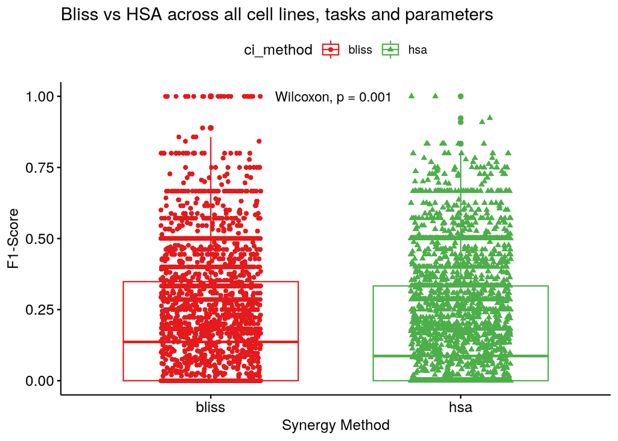

```r
ggboxplot(data = res.data, x = "ci_method", y = "f1.score",
  title = "Bliss vs HSA across all cell lines, tasks and parameters",
  xlab = "Synergy Method", ylab = "F1-Score", color = "ci_method",
  add = "jitter", palette = c("#E41A1C", "#4DAF4A"), shape = "ci_method") +
  stat_compare_means(label.x = 1.35)
```

Seems that there is a **small difference in favor of the bliss-related tasks**

Let’s check if the same trend can be seen when we split the raw data per cell line:

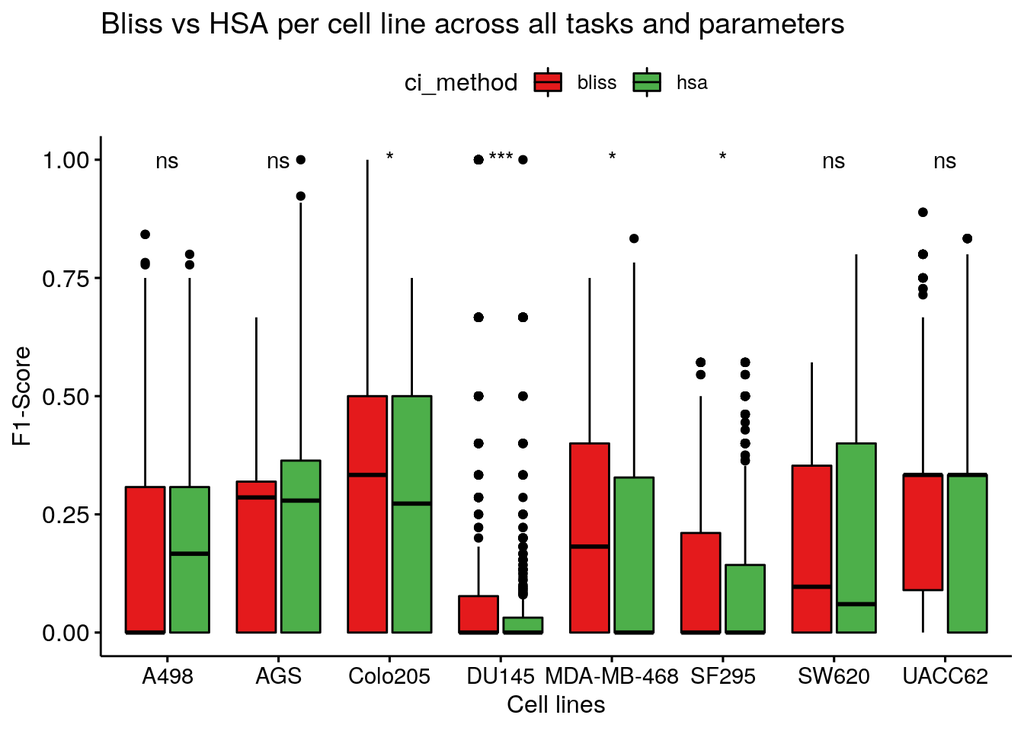

```r
ggboxplot(data = res.data, x = "cell_line", y = "f1.score", fill = "ci_method",
  title = "Bliss vs HSA per cell line across all tasks and parameters",
  xlab = "Cell lines", ylab = "F1-Score", palette = c("#E41A1C", "#4DAF4A")) +
  stat_compare_means(aes(group = ci_method), label = "p.signif") +
  theme(axis.text.x = element_text(size = 11))
```

- For 5 out of 8 cell lines there is no task with any combination of parameters which managed to match exactly the synergies from the curation gold-standard (**no `F1-Score == 1` for some cell lines**).
- The statistical difference between Bliss and HSA is variant across the cell lines with **at least half of them showing no difference at all**.

Grouping the data per task we have:

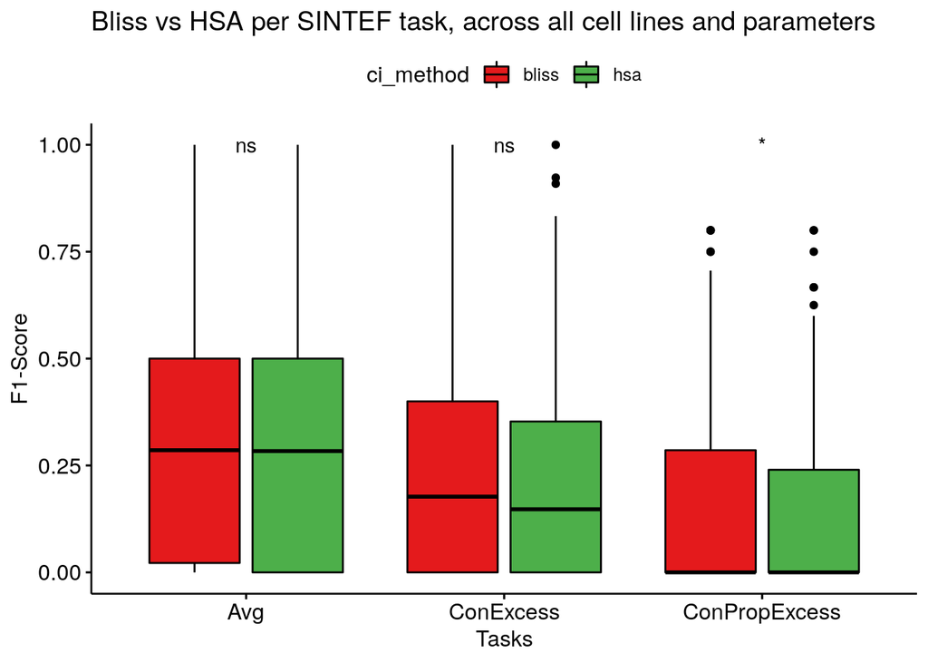

```r
ggboxplot(data = res.data, x = "task", y = "f1.score", fill = "ci_method",
  title = "Bliss vs HSA per SINTEF task, across all cell lines and parameters",
  xlab = "Tasks", ylab = "F1-Score", palette = c("#E41A1C", "#4DAF4A")) +
  stat_compare_means(aes(group = ci_method), label = "p.signif")
```

- There are no parameter combinations in the `ConPropExcess` task for any cell line that produce synergies matching exactly the curated standard synergies in that cell line (`F1-Score` equal to $1$).
- There is **no statistical difference between Bliss and HSA** in the `Avg` and `ConExcess` tasks.
- **Bliss has a statistical significant difference from HSA** in the `ConPropExcess` task.

### Bliss vs HSA (Seperate Tasks)

We will now compare Bliss vs HSA synergy methods for each different task in separate graphs. This will allow us to observe **if in each task there is a small Bliss advantage over HSA, or if it actually depends more on each cell line**:

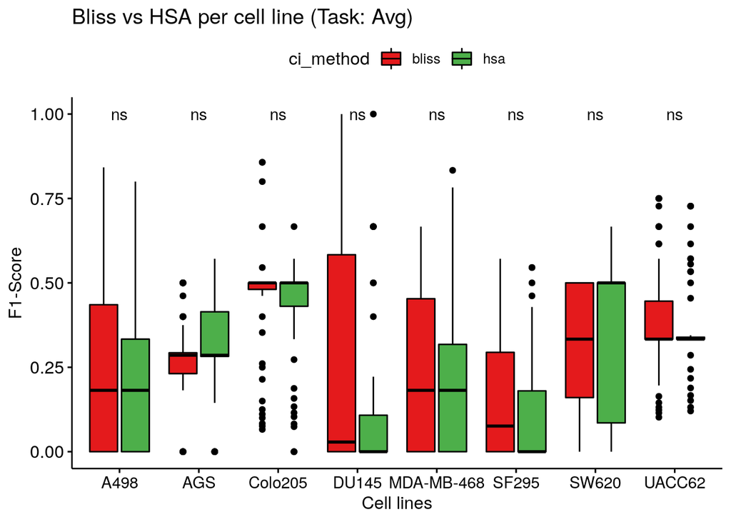

```r
ggboxplot(data = res.data %>% filter(task == "Avg"), x = "cell_line", y = "f1.score",
  fill = "ci_method", title = "Bliss vs HSA per cell line (Task: Avg)",
  xlab = "Cell lines", ylab = "F1-Score", palette = c("#E41A1C", "#4DAF4A")) +
  stat_compare_means(aes(group = ci_method), label = "p.signif") +
  theme(axis.text.x = element_text(size = 11))
```

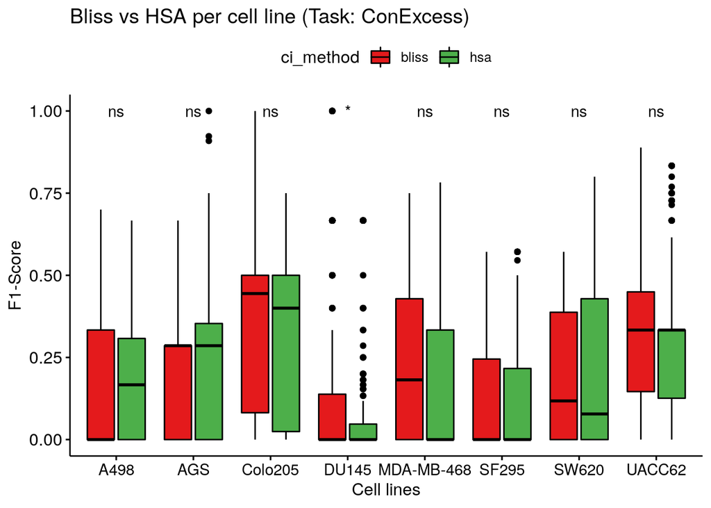

```r
ggboxplot(data = res.data %>% filter(task == "ConExcess"), x = "cell_line", y = "f1.score",
  fill = "ci_method", title = "Bliss vs HSA per cell line (Task: ConExcess)",
  xlab = "Cell lines", ylab = "F1-Score", palette = c("#E41A1C", "#4DAF4A")) +
  stat_compare_means(aes(group = ci_method), label = "p.signif") +
  theme(axis.text.x = element_text(size = 11))
```

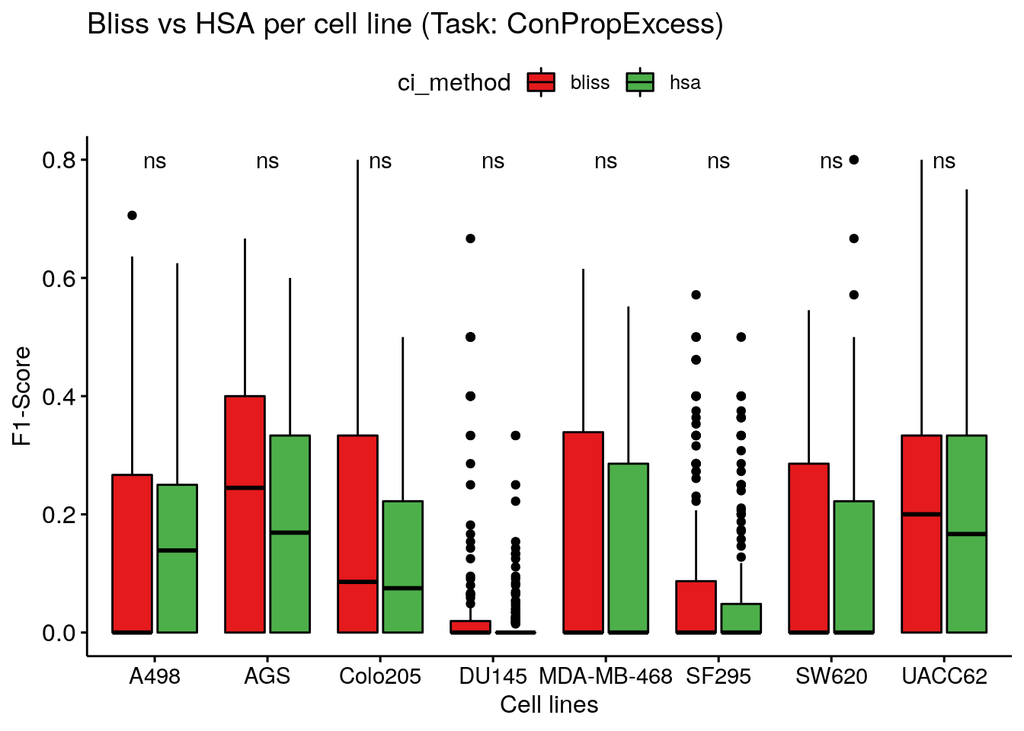

```r
ggboxplot(data = res.data %>% filter(task == "ConPropExcess"), x = "cell_line", y = "f1.score",
  fill = "ci_method", title = "Bliss vs HSA per cell line (Task: ConPropExcess)",
  xlab = "Cell lines", ylab = "F1-Score", palette = c("#E41A1C", "#4DAF4A")) +
  stat_compare_means(aes(group = ci_method), label = "p.signif") +
  theme(axis.text.x = element_text(size = 11))
```

- There is **no strong difference between Bliss vs HSA methods in the same SINTEF task across all cell lines**. So the choice of cell line seems to not play an important role.
- But no matter the task, **there is most of the times a Bliss method that will outperform any HSA-based one, in any given cell line**.

### Bliss vs HSA (Correlation)

Now we tidy our raw data, in order to compare **homogenous data points** - i.e. coming from the same task, parameters and cell line, only different synergy method (Bliss vs HSA).

First for the `Avg` task:

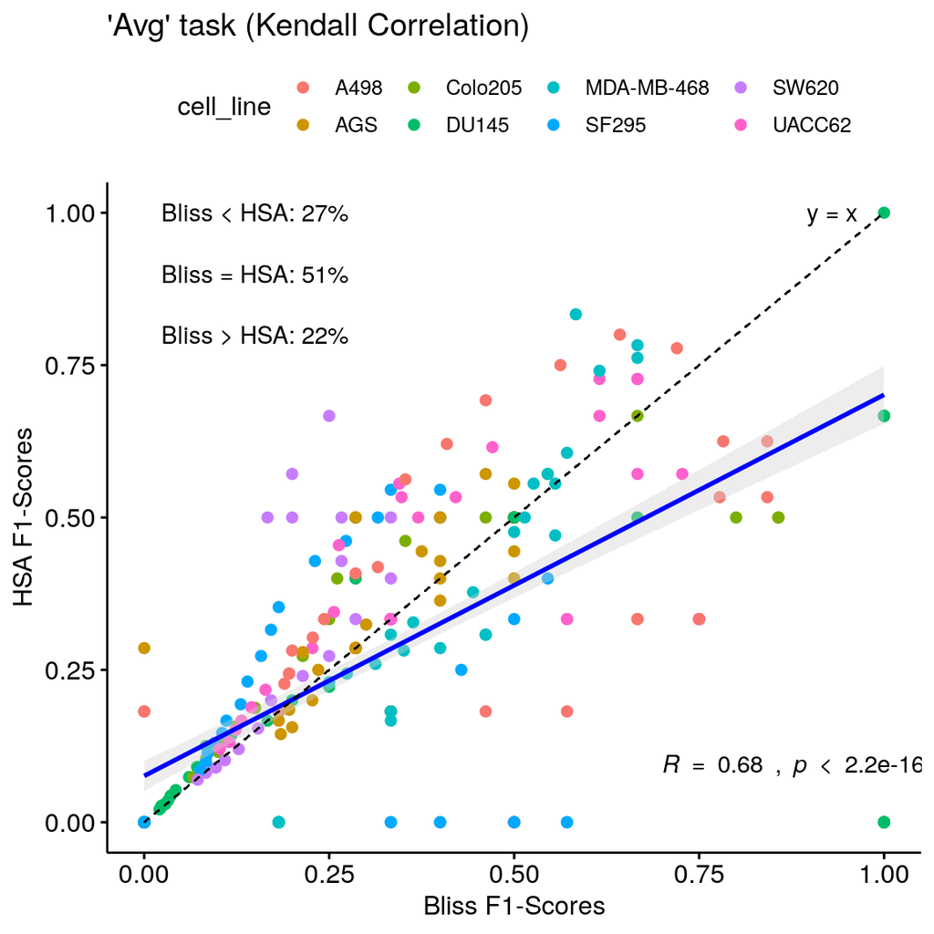

```r
data.task.avg = res.data %>%
  filter(task == "Avg") %>%
  group_by(ci_method) %>%
  arrange(ci_method, excess_threshold, cell_line) %>%
  transmute(cell_line, excess_threshold, f1.score) %>%
  group_split() %>%
  bind_cols()

# count Bliss vs HSA F1-Scores
task.avg.counts = data.task.avg %>%
  transmute(equal = (f1.score == f1.score1), less = (f1.score < f1.score1), larger = (f1.score > f1.score1)) %>%
  summarise(equal = sum(equal), less = sum(less), larger = sum(larger))

ggscatter(data = data.task.avg, x = "f1.score", y = "f1.score1", color = "cell_line",
  xlab = "Bliss F1-Scores", ylab = "HSA F1-Scores",
  title = "'Avg' task (Kendall Correlation)",
  add = "reg.line", add.params = list(color = "blue", fill = "lightgray"),
  conf.int = TRUE, cor.coef = TRUE,
  cor.coeff.args = list(method = "kendall", label.x.npc = 0.7, label.y.npc = 0.1)) +
  geom_segment(x = 0, y = 0, xend = 1, yend = 1, size = 0.3, linetype = "dashed") +
  annotate(geom = "text", label = "y = x", x = 0.93, y = 1) +
  annotate(geom = "text", label = paste0("Bliss < HSA: ", signif(100*task.avg.counts$less/sum(task.avg.counts), digits = 2), "%"), x = 0.15, y = 1) +
  annotate(geom = "text", label = paste0("Bliss = HSA: ", signif(100*task.avg.counts$equal/sum(task.avg.counts), digits = 2), "%"), x = 0.15, y = 0.9) +
  annotate(geom = "text", label = paste0("Bliss > HSA: ", signif(100*task.avg.counts$larger/sum(task.avg.counts), digits = 2), "%"), x = 0.15, y = 0.8)
```

Next for the `ConExcess` task:

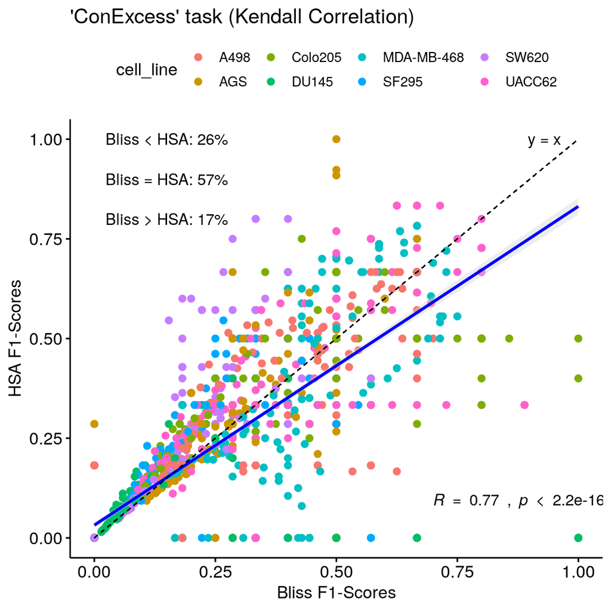

```r
data.task.con.excess = res.data %>%
  filter(task == "ConExcess") %>%
  group_by(ci_method) %>%
  arrange(ci_method, consecutive_excess_count, excess_threshold, cell_line) %>%
  transmute(consecutive_excess_count, excess_threshold, cell_line, f1.score) %>%
  group_split() %>%
  bind_cols()

# count Bliss vs HSA F1-Scores
task.con.excess.counts = data.task.con.excess %>%
  transmute(equal = (f1.score == f1.score1), less = (f1.score < f1.score1), larger = (f1.score > f1.score1)) %>%
  summarise(equal = sum(equal), less = sum(less), larger = sum(larger))

ggscatter(data = data.task.con.excess, x = "f1.score", y = "f1.score1", color = "cell_line",
  xlab = "Bliss F1-Scores", ylab = "HSA F1-Scores",
  title = "'ConExcess' task (Kendall Correlation)",
  add = "reg.line", add.params = list(color = "blue", fill = "lightgray"),
  conf.int = TRUE, cor.coef = TRUE,
  cor.coeff.args = list(method = "kendall", label.x.npc = 0.7, label.y.npc = 0.1)) +
  geom_segment(x = 0, y = 0, xend = 1, yend = 1, size = 0.3, linetype = "dashed") +
  annotate(geom = "text", label = "y = x", x = 0.93, y = 1) +
  annotate(geom = "text", label = paste0("Bliss < HSA: ", signif(100*task.con.excess.counts$less/sum(task.con.excess.counts), digits = 2), "%"), x = 0.15, y = 1) +
  annotate(geom = "text", label = paste0("Bliss = HSA: ", signif(100*task.con.excess.counts$equal/sum(task.con.excess.counts), digits = 2), "%"), x = 0.15, y = 0.9) +
  annotate(geom = "text", label = paste0("Bliss > HSA: ", signif(100*task.con.excess.counts$larger/sum(task.con.excess.counts), digits = 2), "%"), x = 0.15, y = 0.8)
```

Lastly, for the `ConPropExcess` task:

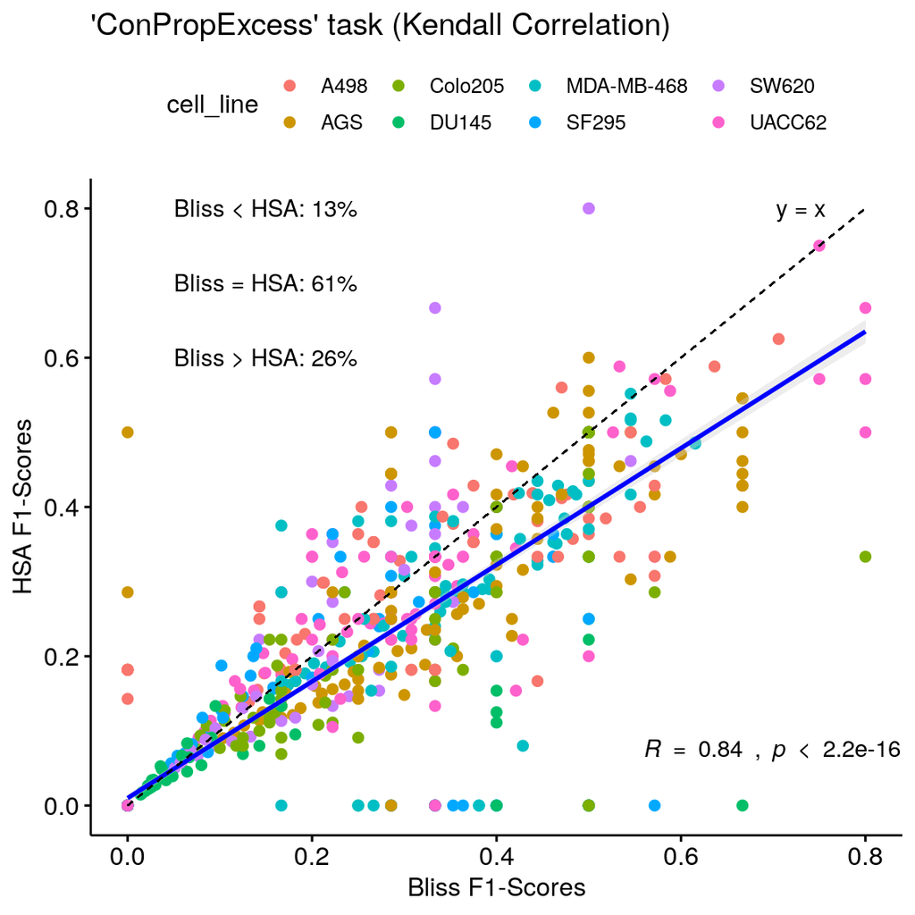

```r
data.task.con.prop.excess = res.data %>%
  filter(task == "ConPropExcess") %>%
  group_by(ci_method) %>%
  arrange(ci_method, consecutive_excess_count, excess_proportional_threshold, cell_line) %>%
  transmute(consecutive_excess_count, excess_proportional_threshold, cell_line, f1.score) %>%
  group_split() %>%
  bind_cols()

# count Bliss vs HSA F1-Scores
task.con.prop.excess.counts = data.task.con.prop.excess %>%
  transmute(equal = (f1.score == f1.score1), less = (f1.score < f1.score1), larger = (f1.score > f1.score1)) %>%
  summarise(equal = sum(equal), less = sum(less), larger = sum(larger))

ggscatter(data = data.task.con.prop.excess, x = "f1.score", y = "f1.score1", color = "cell_line",
  xlab = "Bliss F1-Scores", ylab = "HSA F1-Scores",
  title = "'ConPropExcess' task (Kendall Correlation)",
  add = "reg.line", add.params = list(color = "blue", fill = "lightgray"),
  conf.int = TRUE, cor.coef = TRUE,
  cor.coeff.args = list(method = "kendall", label.x.npc = 0.7, label.y.npc = 0.1)) +
  geom_segment(x = 0, y = 0, xend = 0.8, yend = 0.8, size = 0.3, linetype = "dashed") +
  annotate(geom = "text", label = "y = x", x = 0.73, y = 0.8) +
  annotate(geom = "text", label = paste0("Bliss < HSA: ", signif(100*task.con.prop.excess.counts$less/sum(task.con.prop.excess.counts), digits = 2), "%"), x = 0.15, y = 0.8) +
  annotate(geom = "text", label = paste0("Bliss = HSA: ", signif(100*task.con.prop.excess.counts$equal/sum(task.con.prop.excess.counts), digits = 2), "%"), x = 0.15, y = 0.7) +
  annotate(geom = "text", label = paste0("Bliss > HSA: ", signif(100*task.con.prop.excess.counts$larger/sum(task.con.prop.excess.counts), digits = 2), "%"), x = 0.15, y = 0.6)
```

- Bliss results correlate with HSA ones more on `ConPropExcess` task, less on the `ConExcess` task and even less on the `Avg` task. So the **more sophisticated** the method is, the **larger the correlation** between Bliss and HSA (more common F1-Scores).
- **In more than half of the data points** collected across all cell lines and task parameters, **Bliss produces an equal F1-Score with the HSA-based methods**.
- Where the results between Bliss and HSA differ:
  - In the `Avg` and `ConExcess` tasks, **HSA has a larger percentage of F1-Scores** ($\sim5\%$ and $\sim 9\%$ difference respectively).
  - In the `ConPropExcess` task, **Bliss has a larger percentage of F1-Scores** ($\sim 13\%$ difference).
- The above reflects the results of this figure which shows Bliss having a statistical significant difference from HSA for the `ConPropExcess` task. This also means that the value differences of the F1-Scores between HSA and Bliss are larger in magnitude in the `ConPropExcess` task compared to the other two tasks (since the difference percentages somewhat negate each other across the 3 tasks but there is a difference in the overall data in favor of Bliss).
- In all 3 graphs above, **the regression line is below the `y=x` line** which means that there are higher Bliss values produced by some methods (no matter the task or cell line): these **(outlier-sort-of) Bliss results outperform the HSA similar ones**.

Our job now is to find the task with the set of parameters that will give the best HSA or Bliss-based F1-score across all the cell lines tested.

# Bliss-all-combinations method

Barbara’s **Bliss-all-combinations method** (I arbitrarily chose the name) was the method that she and Asmund used in (Flobak et al. 2019) in the data from the first screen to find and visualize the synergies across all 8 cell lines. The method is described in the text and Asmund wrote an *R* script that calculates the **average Bliss excesses** and **significance scores** (*p_values_Bliss.R* in the supplementary material - generates the bliss_significance.tsv file). Combinations with **average Bliss excess values** $<−0.08$ and *p-value* $<0.05$ (the *Bonferroni*-corrected) were classified as synergies (results were put into the bliss_synergies.tsv file in the SI of the paper).

```r
bliss.all.comb.data = drop_na(read_tsv(file = "bliss_significance.tsv"))
bliss.synergies = read_tsv(file = "bliss_synergies.tsv")

# Fix the cell line names
bliss.all.comb.data = bliss.all.comb.data %>%
  mutate(cell_line = case_when(
    cell_line == "SW-620" ~ "SW620",
    cell_line == "COLO 205" ~ "Colo205",
    cell_line == "DU-145" ~ "DU145",
    cell_line == "SF-295" ~ "SF295",
    cell_line == "UACC-62" ~ "UACC62",
    TRUE ~ cell_line
))
bliss.synergies = bliss.synergies %>%
  mutate(cell_line = case_when(
    cell_line == "SW-620" ~ "SW620",
    cell_line == "COLO 205" ~ "Colo205",
    cell_line == "DU-145" ~ "DU145",
    cell_line == "SF-295" ~ "SF295",
    cell_line == "UACC-62" ~ "UACC62",
    TRUE ~ cell_line
))

# below results are the same
# cell.line = "AGS"
# bliss.all.comb.data %>%
#   filter(p.value.bonferroni < 0.05, mean.bliss.estimate < -0.08, cell_line == cell.line) %>%
#   filter(!grepl('SF', drugcombo))
# bliss.synergies %>% filter(cell_line == cell.line, !grepl('SF', drugcombo))
```

# Rbbt: Compare HSA Results (TO DELETE)

Consider this to be a *side-quest* investigation!

## Aim

Compare two results:

1. **HSA-based synergies that Vasundra used in INSIDE** (INfluential NoDE AnalySIs, **4 cell lines**) - included in Barbara’s modeling paper
2. **Barbara’s HSA results** in rbbt’s `observed_synergies_averaged` task (which takes as input a file that she had given to Miguel a while ago and which she said to me once that she has everything there *averaged*).

## Compare Results

Note that we did some task renaming in rbbt’s `SINTEF` workflow tasks so the R code for this section to run needs a `SINTEF` workflow that is no further than the commit **d1a2e5**! (the task `observed_synergies_averaged` that used Barbara’s file **is no longer used**). Thus, the following code is shown but not executed in this current version of the document.

Getting the results in appropriate format:

```r
# File with the synergies as used in the Influential Node Analysis (that Vasundra gave me!)
inside.obs.synergies.file = paste0(getwd(), "/20190205_Synergy_HSA.txt")
df = read.table(file = inside.obs.synergies.file, header = TRUE, sep = "\t")

# Turn FALSE,TRUE to 0,1
cols = sapply(df, is.logical)
df[,cols] = lapply(df[,cols], as.numeric)

# AGS
ags.obs = df %>% filter(AGS == 1) %>% select(Combination)
ags.obs.synergies = as.character(ags.obs$Combination)
ags.obs.synergies = sort(ags.obs.synergies)

ags.obs.2 = rbbt.job("SINTEF", "observed_synergies_averaged", cell_line="AGS", method="HSA", observed_threshold=-0.11, log="0", type = "array")
ags.obs.synergies.2 = ags.obs.2[!grepl(pattern = "SF", x = ags.obs.2)]
ags.obs.synergies.2 = str_replace_all(string = ags.obs.synergies.2, pattern = "~", replacement = "-")
ags.obs.synergies.2 = sort(ags.obs.synergies.2)

# Colo205
colo205.obs = df %>% filter(COLO205 == 1) %>% select(Combination)
colo205.obs.synergies = as.character(colo205.obs$Combination)
colo205.obs.synergies = sort(colo205.obs.synergies)

colo205.obs.2 = rbbt.job("SINTEF", "observed_synergies_averaged", cell_line="Colo205", method="HSA", observed_threshold=-0.11, log="0", type = "array")
colo205.obs.synergies.2 = colo205.obs.2[!grepl(pattern = "SF", x = colo205.obs.2)]
colo205.obs.synergies.2 = str_replace_all(string = colo205.obs.synergies.2, pattern = "~", replacement = "-")
colo205.obs.synergies.2 = sort(colo205.obs.synergies.2)

# DU145
du145.obs = df %>% filter(DU145 == 1) %>% select(Combination)
du145.obs.synergies = as.character(du145.obs$Combination)
du145.obs.synergies = sort(du145.obs.synergies)

du145.obs.2 = rbbt.job("SINTEF", "observed_synergies_averaged", cell_line="DU145", method="HSA", observed_threshold=-0.11, log="0", type = "array")
du145.obs.synergies.2 = du145.obs.2[!grepl(pattern = "SF", x = du145.obs.2)]
du145.obs.synergies.2 = str_replace_all(string = du145.obs.synergies.2, pattern = "~", replacement = "-")
du145.obs.synergies.2 = sort(du145.obs.synergies.2)

# SW620
sw620.obs = df %>% filter(SW620 == 1) %>% select(Combination)
sw620.obs.synergies = as.character(sw620.obs$Combination)
sw620.obs.synergies = sort(sw620.obs.synergies)

sw620.obs.2 = rbbt.job("SINTEF", "observed_synergies_averaged", cell_line="SW620", method="HSA", observed_threshold=-0.11, log="0", type = "array")
sw620.obs.synergies.2 = sw620.obs.2[!grepl(pattern = "SF", x = sw620.obs.2)]
sw620.obs.synergies.2 = str_replace_all(string = sw620.obs.synergies.2, pattern = "~", replacement = "-")
sw620.obs.synergies.2 = sort(sw620.obs.synergies)
```

Comparing them:

```r
# Everything here executed with not errors (vectors were the same)
stopifnot(all(ags.obs.synergies == ags.obs.synergies.2))
stopifnot(all(colo205.obs.synergies == colo205.obs.synergies.2))
stopifnot(all(du145.obs.synergies == du145.obs.synergies.2))
stopifnot(all(sw620.obs.synergies == sw620.obs.synergies.2))
```

# References

Flobak, Åsmund, Barbara Niederdorfer, Vu To Nakstad, Liv Thommesen, Geir Klinkenberg, and Astrid Lægreid. 2019. “A high-throughput drug combination screen of targeted small molecule inhibitors in cancer cell lines.” *Scientific Data* 6 (1): 237. https://doi.org/10.1038/s41597-019-0255-7.

Flobak, Åsmund, Miguel Vazquez, Astrid Lægreid, and Alfonso Valencia. 2017. “CImbinator: a web-based tool for drug synergy analysis in small- and large-scale datasets.” Edited by Jonathan Wren. *Bioinformatics* 33 (15): 2410–2. https://doi.org/10.1093/bioinformatics/btx161.

[^1]: The *Gold standard* is actually taken from [an online file](https://docs.google.com/spreadsheets/d/1Uyi-jpC2xNd4hWvtMILssXEFk8yHmk26xKhTVnZ1H7o/edit?usp=sharing) that has the results from a manual/visual inspection of the SINTEF dataset (the dose-response curves) and it’s a consensus of three curators: **Asmund Flobak, Barbara Niederdorfer and Evelina Folkesson**. The `synergy_classification_by_GS` task from the rbbt `SINTEF` workflow has to be at least on the `2c5ea` commit to take the latest version of that file
[^2]: Computed from the `bliss` and `hsa` CombinationIndex task results and not taken directly from Barbara’s file any more as it was done with the `observed_synergies_averaged` task (i.e. on the SINTEF workflow commit `d1a2e5` and before)
[^3]: Also uses the `bliss` and `hsa` CombinationIndex task results
[^4]: Also uses the `bliss` and `hsa` CombinationIndex task results